# Group L Project Proposal - Migration and Industry Trends

Yihong Liu & Zu Cheng Mark Ong

10/03/2019

**Title**: Evolution of migration flow patterns and industry trends over time

**Abstract**: We are interested in looking at migration flows and industry patterns across countries. We will explore the following questions:

- How does migration flow evolved over time (in terms of volume of migration, countries with major inflow of migrants, countries with major outflow of migrants, etc)
  - We plan to plot migration data, over a time series, on maps
  - We can look at migration flow between countries and/or between regions/continents. Grouping the data by continents/regions might show a clear visualization of the broad dispplacement pattern of humans. as compared to plotting data at country-level.
  - Which countries observed the greatest increase in immigrants over time?
  - We can look at the net migration of each country/region/continent over time, which is the difference between the number of immigrants (people coming into an area) and the number of emigrants (people leaving an area)
- How do the top industries of countries change over time?
  - Specifically, we want to look at the top n industries for each of the top n countries in term of number of immigrants
  - We would also want to find out what are the common major industries among the countries with greatest inflow of migrants. We hope to gain insight on relationships (if any) between industry trends and migration flow trends.
- What do the sentiments towards immigrants change over time?
  - If feasible, we plan to analyze sentiments from twitter data, whether ‘migration’ is typically mentioned alongside with positive or negative words
  - To limit the scale of this project, we might choose to focus on the top n countries in terms of number of immigrants, or top n countries in terms of sum of immigrants and emigrants (total number of people moving in and out of the country)

**Data Visualization Techniques**:

- We expect to use maps for the main visualization of migration flows over time. Ideally, this is a ‘moving’ visualiztion (on loop) that shows the actual movement of migrants over the map, over the years.
- We expect to plot another interactive map. For this map, users can click on the country of interest to gain information about the number of immigrants, number of emigrants, GDP, top n industries, etc for a specified year of interest.
- We expect to use static images/interactive plots based on ggplot2 to present the top industries of each of the countries with greatest number of immigrants. It will also be used to present the common major industries among countries with greatest inflow of migrants.
- We expect to provide static visualization of text analyses. These visualizations would be used to present a sentiment analysis (towards immigrants) conducted on countries facing an influx of immigrants.

**Data**: For our analysis, we would required data from a few areas. We might have to combine data from existing datasets, and use twitter API to collect additional data that is relevant to our project.

- International migration stock at mid-year by major region, country or area, 1990 - 2017 (from United Nations, Department of Economic and Social Affairs. Population Division (2017)):  
  http://www.un.org/en/development/desa/population/migration/data/estimates2/estimates17.asp
  - This country-level dataset has collected data of international migrant by age, sex, destination, and origin. Estimates are presented for 1990, 1995, 2000, 2005, 2010, 2015 and 2017 and are available for all countries and areas of the world.
  - This will be used for the ‘moving’ visualization, in which we use geographical identifiers (countries / regions) to plot the movement of migrants between countries/regions over time
    - Ideally, we can further breakdown the data by gender, or age groups to provide a more informative data visualization
  - This will also be used for identify the top n countries with greatest inflow of migrants, greatest net migration, etc for some of our plots.
- Value added by activity, 1970 - 2017(from UNdata):  
  http://data.un.org/Data.aspx?d=SNAAMA&f=grID%3A201%3BcurrID%3ANCU%3BpcFlag%3A0
  - This country-level dataset contains annual value-added-by-activity (e.g. agriculture, mining, construction, financial, etc) of each country from 1970 to 2017. Value added by activity breaks down the total value added by sector. It could be used to reflect the contribution of industries to the overall economy.
  - This will be used for the plots that look at top n industries for a group of countries of interest.
  - This will also be used for the plot that looks at the common major industries among the countries with greatest inflow of migrants.
- GDP data of all countries and economies, 1960 - 2017 (from World Bank Open Data):  
  https://data.worldbank.org/indicator/NY.GDP.MKTP.CD?year_low_desc=false
  - This country-level dataset includes annual GDP(current US$) data for all countries and economies.
  - This data will be used for our interactive plot. GDP information will be provided along with information about ‘top industries’ of each country of interest.
- Twitter API data:  
  https://developer.twitter.com/en/docs/tweets/rules-and-filtering/overview/premium-operators
  - The text data extracted will be used to carry out sentiment analysis towards immigrants.

**Final Product Preview**:

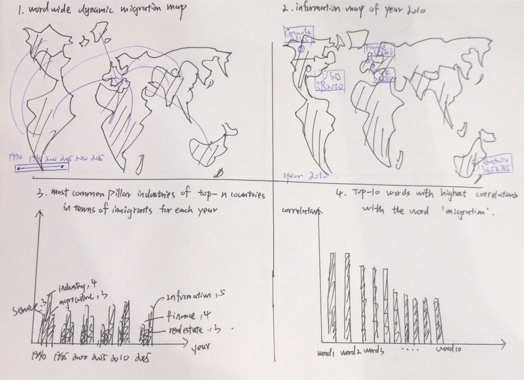